# Homework-3

Francesca Pecorari

2023-11-30

## Creazione piano sperimentale

Creare un piano sperimentale con 16 esperimenti secondo un fattoriale completo $2^4$ contenente i seguenti fattori:

• A = feed rate: slow o medium • B = initial inoculant size (300g - 700g) • C = feed substrate concentration (40 g/L - 60 g/L) • D = dissolved oxygen set-point (4mg/L - 6 mg/L)

```r
A = c(-1,1,-1,1,-1,1,-1,1,-1,1,-1,1,-1,1,-1,1)
B = c(-1,-1,1,1,-1,-1,1,1,-1,-1,1,1,-1,-1,1,1)
C = c(-1,-1,-1,-1,1,1,1,1,-1,-1,-1,-1,1,1,1,1)
D = c(-1,-1,-1,-1,-1,-1,-1,-1,1,1,1,1,1,1,1,1)

mydf<- data.frame(A,B,C,D)
```

## Aggiunta variabile risposta

Aggiungere al data.frame del piano creato precedentemente una colonna con la variabile risposta Resa = [60, 59, 63, 61, 69, 61, 94, 93, 56, 63, 70, 65, 44, 45, 78, 77].

```r
Resa = c(60, 59, 63, 61, 69, 61, 94, 93, 56, 63, 70, 65, 44, 45, 78, 77)

mydf<- cbind(mydf, Resa)
```

## Analisi piano

Dopo aver scelto un modello per l’analisi del piano creato precedentemente, si identifichino gli effetti significativi utilizzando almeno due strumenti grafici diversi.

Partiamo considerando il modello con tutte le interazioni.

```r
mod <- lm(Resa ~ A*B*C*D,
          data=mydf)# Modello con tutte le interazioni

summary(mod)
```

```
##
## Call:
## lm.default(formula = Resa ~ A * B * C * D, data = mydf)
##
## Residuals:
## ALL 16 residuals are 0: no residual degrees of freedom!
##
## Coefficients:
##             Estimate Std. Error t value Pr(>|t|)
## (Intercept)   66.125        NaN     NaN      NaN
## A             -0.625        NaN     NaN      NaN
## B              9.000        NaN     NaN      NaN
## C              4.000        NaN     NaN      NaN
## D             -3.875        NaN     NaN      NaN
## A:B           -0.500        NaN     NaN      NaN
## A:C           -0.500        NaN     NaN      NaN
## B:C            6.375        NaN     NaN      NaN
## A:D            0.875        NaN     NaN      NaN
## B:D            1.250        NaN     NaN      NaN
## C:D           -5.250        NaN     NaN      NaN
## A:B:C          1.125        NaN     NaN      NaN
## A:B:D         -1.250        NaN     NaN      NaN
## A:C:D          0.250        NaN     NaN      NaN
## B:C:D         -0.125        NaN     NaN      NaN
## A:B:C:D        0.125        NaN     NaN      NaN
##
## Residual standard error: NaN on 0 degrees of freedom
## Multiple R-squared:      1,  Adjusted R-squared:    NaN
## F-statistic:   NaN on 15 and 0 DF,  p-value: NA
```

Utilizzando un modello che considera tutte le interazioni possibili tra le variabili, non ci rimangono gradi di libertà per stimare l’incertezza dei coefficienti, proviamo quindi a considerare un modello che non tiene conto delle interazioni a quattro tra i fattori in modo da ottenere un grado di libertà per capire se la stima fatta è significativa.

```r
mod1 <- lm(Resa ~ (A+B+C+D)^3,
          data=mydf)# Modello con le interazioni a tre

summary(mod1)
```

```
##
## Call:
## lm.default(formula = Resa ~ (A + B + C + D)^3, data = mydf)
##
## Residuals:
##      1      2      3      4      5      6      7      8      9     10     11
##  0.125 -0.125 -0.125  0.125 -0.125  0.125  0.125 -0.125 -0.125  0.125  0.125
##     12     13     14     15     16
## -0.125  0.125 -0.125 -0.125  0.125
##
## Coefficients:
##             Estimate Std. Error t value Pr(>|t|)
## (Intercept)   66.125      0.125     529  0.00120 **
## A             -0.625      0.125      -5  0.12567
## B              9.000      0.125      72  0.00884 **
## C              4.000      0.125      32  0.01989 *
## D             -3.875      0.125     -31  0.02053 *
## A:B           -0.500      0.125      -4  0.15596
## A:C           -0.500      0.125      -4  0.15596
## A:D            0.875      0.125       7  0.09033 .
## B:C            6.375      0.125      51  0.01248 *
## B:D            1.250      0.125      10  0.06345 .
## C:D           -5.250      0.125     -42  0.01515 *
## A:B:C          1.125      0.125       9  0.07045 .
## A:B:D         -1.250      0.125     -10  0.06345 .
## A:C:D          0.250      0.125       2  0.29517
## B:C:D         -0.125      0.125      -1  0.50000
## ---
## Signif. codes:  0 '***' 0.001 '**' 0.01 '*' 0.05 '.' 0.1 ' ' 1
##
## Residual standard error: 0.5 on 1 degrees of freedom
## Multiple R-squared:  0.9999, Adjusted R-squared:  0.9987
## F-statistic: 851.9 on 14 and 1 DF,  p-value: 0.02685
```

La stima dell’errore del coefficiente è uguale per tutti i coefficienti, questo è dovuto alla matrice di dispersione del modello, i cui termini sulla diagonale sono tutti uguali. Notiamo che è stato possibile calcolare l’ R^2 aggiustato e che questo è molto alto, quasi uguale a uno. Riusciamo anche ad avere un’idea di quali coefficienti siano significativi:

- B: initial inoculant size (molto significativa)
- C: feed substrate concentration
- D: dissolved oxygen set-point
- l’interazione tra A (feed rate) e D
- l’interazione tra B e C
- l’interazione tra B e D
- l’interazione tra B e C
- l’interazione tra C e D
- l’interazione tra A, B e C
- l’interazione tra A, B e D

Valutiamo la bontà del modello di regressione facendo un plot di valori reali vs. valori predetti e, in questo caso, lo facciamo in autopredizione.

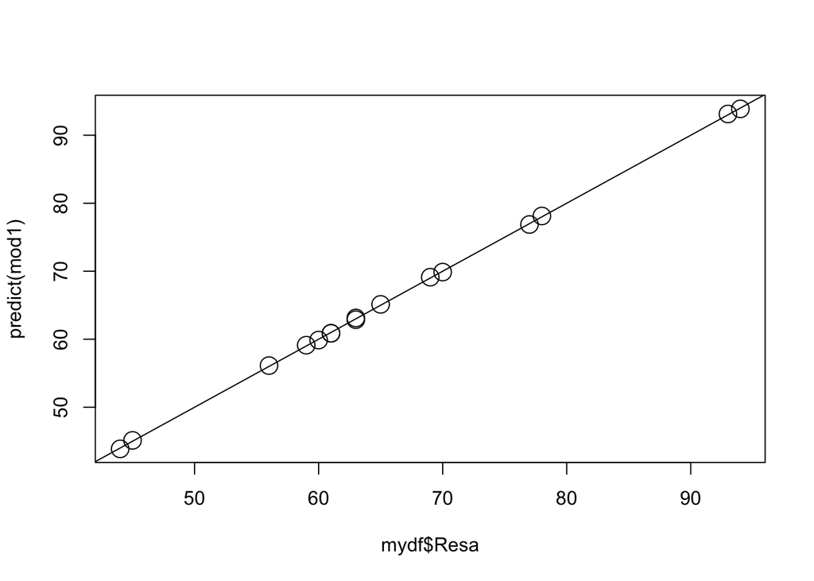

```r
plot(mydf$Resa, predict(mod1), cex=2)
abline(0,1, cex=1)
```

Il nostro modello funziona molto bene in autopredizione, tutti i valori sono posizionati sulla bisettrice del nostro sistema.

#### Grafico dei coefficienti con intervallo di confidenza

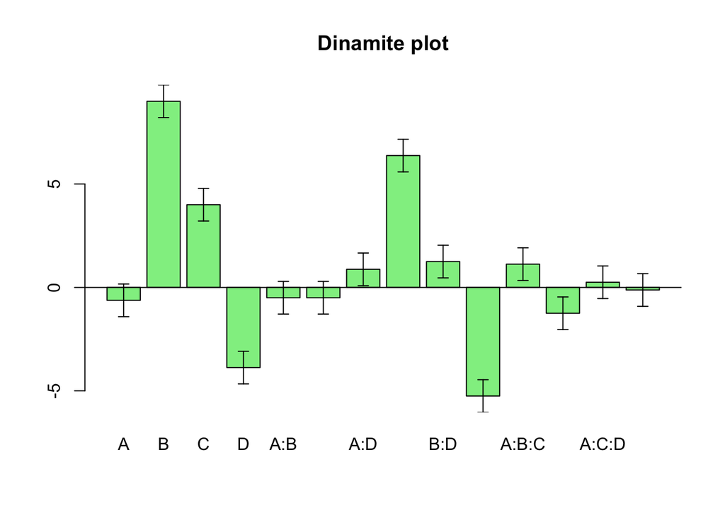

```r
#Grafico dei coefficienti con intervallo di confidenza
out<-summary(mod1)
c0 <- coef(mod1)[-1]
cc <- confint(mod1, level = 0.90)[-1,] # ottenere la stima dell'intervallo di confidenza impostando il livello di confidenza
b <- drop(barplot(c0,ylim=range(c(cc)), col= "lightgreen", main= "Dinamite plot"))
arrows(b,c0,b,cc[,1],angle=90,length=0.05) ## limite inferiore
arrows(b,c0,b,cc[,2],angle=90,length=0.05) ## limite superiore
abline(0,0)
```

Dal dinamite plot notiamo che vengono confermate le considerazioni fatte interpretando il summary, vediamo che i coefficienti considerati non significativi sono quelli che hanno le barre che attraversano lo zero.

#### Grafico di Lenth

Un altro modo per verificare la significatività dei coefficienti che è valido anche quando non si hanno a disposizione gradi di libertà o stime esterne è il metodo di Lenth. Il metodo è non paramentrico, questo significa che non fa assunzioni sulla distribuzione dei campioni.

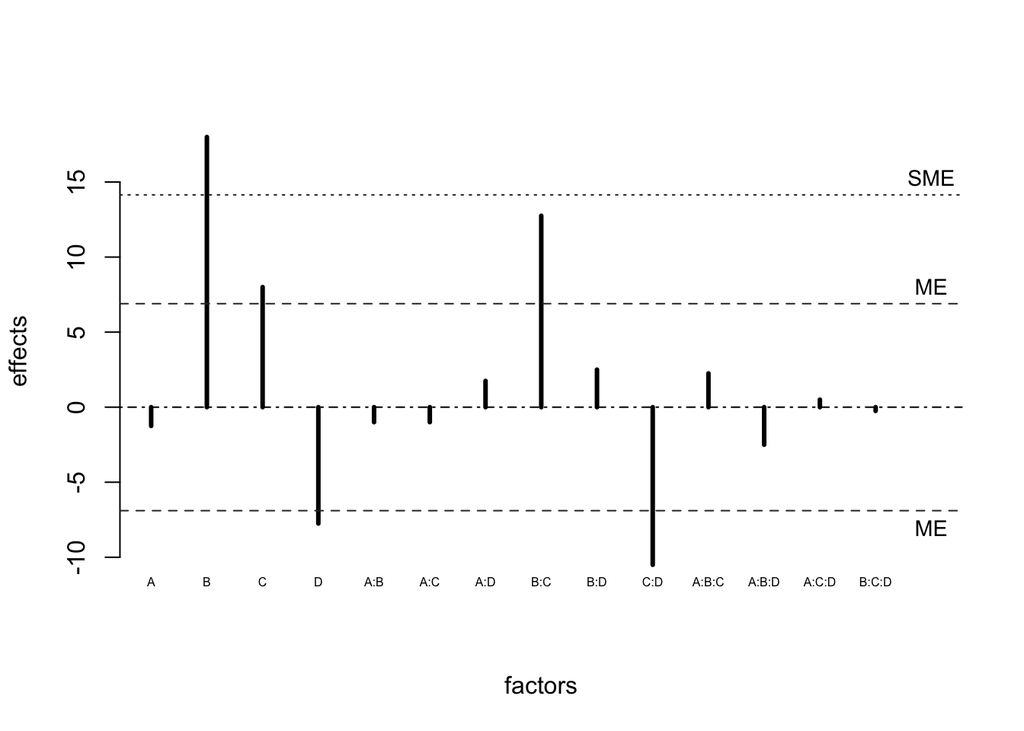

```
##     alpha       PSE        ME       SME
##  0.050000  2.625000  6.895357 14.144747
```

```r
# Metodo di Lenth

# Grafico
LenthPlot(mod1,cex.fac = 0.5)
```

Il grafico mostra delle barre verticali che rappresentano la stima dei coefficienti e delle linee tratteggiate orizzontali corrispondenti a degli pseudo-intervalli di confidenza che si utilizzano per stabilire quali coefficienti sono significativi.

Notiamo che il coefficiente per B risulta essere sicuramente significativo, in quanto supera anche la seconda soglia degli pseudo-intervalli. In questo caso, possiamo affermare che un numero inferiore di coefficienti viene considerato significativo rispetto ai risultati ottenuti con il summary, ad esempio, nessuna delle interazione a tre è considerata come significativa.

#### Grafici degli effetti

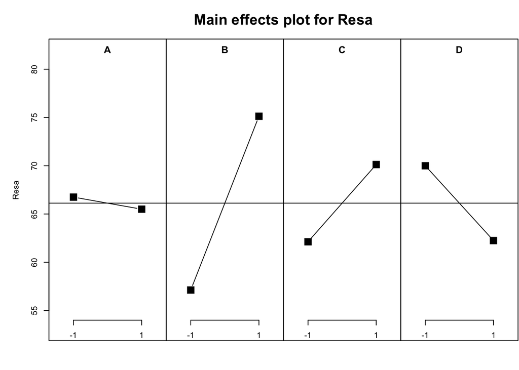

```r
MEPlot(mod1) # effetti principali
```

Sopra è rappresentato il plot degli effetti principali. Si possono fare le sefuenti osservazioni:

- l’effetto di A è minimo e leggermente negativo
- l’effetto di B è quello più importante ed è positivo
- l’ effetto di C è positivo
- l’effetto di D è negativo

Si può ottenere anche il plot delle interazioni.

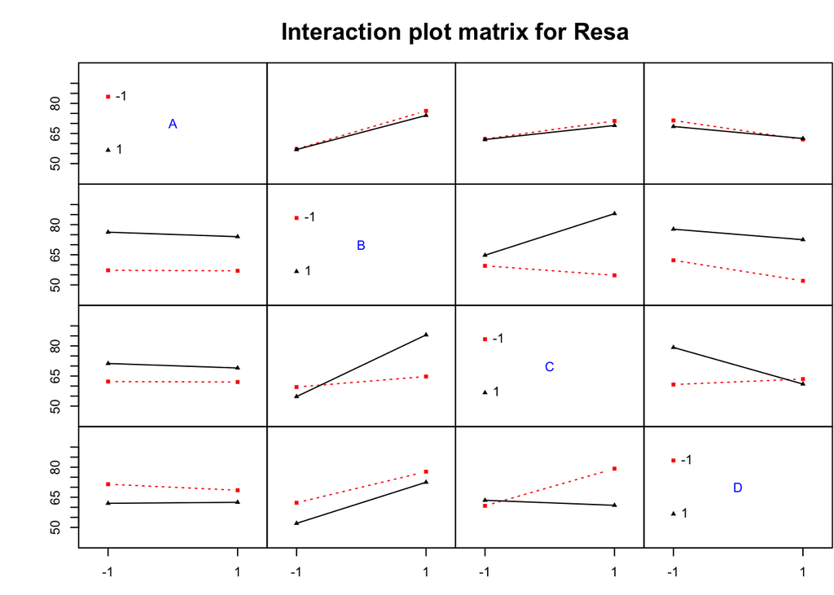

```r
IAPlot(mod1) # interazioni
```

Lo si vede in maniera più chiara costruendo i singoli interaction plots.

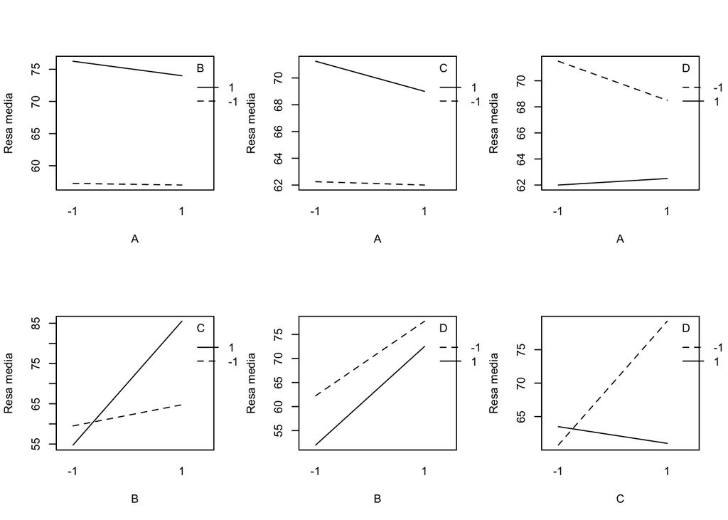

```r
#Interactions plot

par(mfrow=c(2,3))
interaction.plot(mydf$A, mydf$B, mydf$Resa, type = "l",
                 xlab = "A",trace.label = "B",
                 ylab = "Resa media")

interaction.plot(mydf$A, mydf$C,mydf$Resa, type = "l",
                 xlab = "A",trace.label = "C",
                 ylab = "Resa media")

interaction.plot(mydf$A, mydf$D, mydf$Resa, type = "l",
                 xlab = "A",trace.label = "D",
                 ylab = "Resa media")

interaction.plot(mydf$B, mydf$C, mydf$Resa, type = "l",
                 xlab = "B",trace.label = "C",
                 ylab = "Resa media")

interaction.plot(mydf$B, mydf$D, mydf$Resa, type = "l",
                 xlab = "B",trace.label = "D",
                 ylab = "Resa media")

interaction.plot(mydf$C, mydf$D, mydf$Resa, type = "l",
                 xlab = "C",trace.label = "D",
                 ylab = "Resa media")
```

## (Opzionale)

Supponiamo di avere a disposizione solo 8 esperimenti. Si riporti in dettaglio il piano degli esperimenti che usereste con relativa struttura di confusione.